# An application of an objective prior for the number of degrees of freedom of a multivariate t distribution

[F. Javier Rubio](https://sites.google.com/site/fjavierrubio67/) and Cristiano Villa

14 July, 2017

## A financial application of an objective prior for the number of degrees of freedom of a multivariate t distribution

The [$d$-variate $t$ probability density function](https://en.wikipedia.org/wiki/Multivariate_t-distribution) with $\nu>0$ degrees of freedom (see and for an extensive review of this model) is given by
$$f_d({\bf x}\vert {\mu},{\Sigma},\nu) = \dfrac{\Gamma\left(\dfrac{\nu+d}{2}\right)}{\Gamma\left(\dfrac{\nu}{2}\right)\sqrt{(\pi\nu)^d\vert{\Sigma}\vert}} \left(1+\dfrac{({\bf x}-{\mu})^{T}{\Sigma}^{-1}({\bf x}-{\mu})}{\nu}\right)^{-\frac{\nu+d}{2}},$$
[1] derived a discrete objective prior for the number of degrees of freedom of the multivariate $t$ distribution. This prior is truncated at $\nu_{\max}$, pre-specified by the user, typically $\nu_{\max}=30$ and discrete, see [3] for more details.

**References**

1. [Objective priors for the number of degrees of freedom of a multivariate t distribution and the t-copula](https://arxiv.org/abs/1701.05638)
2. [Kullback Leibler divergence between two multivariate t distributions](http://rpubs.com/FJRubio/DKLt)
3. [An objective prior for the number of degrees of freedom of a multivariate t distribution](http://rpubs.com/FJRubio/PriortKL)

```r
##############################################################################################
# Data from : Statistics and Data Analysis for Financial Engineering pp. 180
##############################################################################################
rm(list=ls())
library(mnormt)
library(mvtnorm)
library(mcmc)
library(Ecdat)
library(knitr)
data(CRSPday, package = "Ecdat")
Y = CRSPday[ , c(5, 7)]

##############################################################################################
# Optimisation step as in the book
##############################################################################################

loglik = function(par){
  mu = par[1:2]
  A = matrix(c(par[3], par[4], 0, par[5]), nrow = 2, byrow = T)
  scale_matrix = t(A) %*% A
  df = par[6]
  -sum(log(dmt(Y, mean = mu, S = scale_matrix, df = df)))
}

A = chol(cov(Y))
start = as.vector(c(apply(Y, 2, mean),A[1, 1], A[1, 2], A[2, 2], 4))
fit_mvt = optim(start, loglik, method = "L-BFGS-B",lower = c(-0.02, -0.02, -0.1, -0.1, -0.1, 2),upper = c(0.02, 0.02, 0.1, 0.1, 0.1, 15), hessian = T)

##############################################################################################
# Optimisation step
##############################################################################################

llt = function(par){
  if(par[3]>0 & par[5]>0 & par[6]>0){
    mu = par[1:2]
    A = matrix(c(par[3], par[4], 0, par[5]), nrow = 2, byrow = T)
    Sigma = t(A) %*% A
    var = dmvt(Y, delta = mu, sigma = Sigma, df = par[6], log = TRUE,type = "shifted")
    return( -sum(var) )
  }
  else return(Inf)
}

loglik(start)
```

```
## [1] -15839.85
```

```r
llt(start)
```

```
## [1] -15839.85
```

```r
OPT = optim(start,llt,control=list(maxit=1000))

# The optimisation implemented here is slightly better
OPT$val
```

```
## [1] -16106.81
```

```r
fit_mvt$val
```

```
## [1] -16105.65
```

```r
OPT$par
```

```
## [1] 0.0004990631 0.0008414805 0.0125729426 0.0026557420 0.0049487891
## [6] 4.1890062126
```

```r
fit_mvt$par
```

```
## [1] 0.0003789236 0.0008317070 0.0126907363 0.0026859493 0.0051011198
## [6] 4.2618395311
```

```r
##############################################################################################
# log prior
##############################################################################################
# Kullback Leibler in two dimensions
rm(d)
d=2 # dimension

# Normalising constant
K <- function(d,nu) (gamma(0.5*(nu+d))/( gamma(0.5*nu)*sqrt((pi*nu)^d) ))

# Kullback Liebler divergence
DKL <- function(nu,nup){
  val1 <- log(K(d,nu)/K(d,nup)) -0.5*(nu+d)*(digamma(0.5*(nu+d))-digamma(0.5*nu))
  tempf <- Vectorize(function(t) (1+t/nu)^(-0.5*(nu+d))*t^(0.5*d-1)*log(1+t/nup))
  int<- integrate(tempf,0,Inf,rel.tol = 1e-9)$value
  val2 <- (K(d,nu)*pi^(0.5*d)*0.5*(nup+d)/gamma(0.5*d))*int
  return(val1+val2)
}

numax = 30

T2 <- matrix(0,ncol=3,nrow=numax)
T2[1,] <- c(1,0,DKL(1,2))
for(i in 2:numax) T2[i,] = c(i,DKL(i,i-1),DKL(i,i+1))
colnames(T2) <- c("nu","DKL(nu,nu-1)","DKL(nu,nu+1)")
rownames(T2) <- 1:numax
print(kable(T2,digits=12))
```

```
##
##
##  nu   DKL(nu,nu-1)   DKL(nu,nu+1)
## ---  -------------  -------------
##   1   0.000000e+00   1.415927e-01
##   2   7.944154e-02   2.732554e-02
##   3   1.956127e-02   9.139055e-03
##   4   7.282898e-03   3.961126e-03
##   5   3.352862e-03   2.005447e-03
##   6   1.763603e-03   1.127459e-03
##   7   1.017649e-03   6.838292e-04
##   8   6.288552e-04   4.393997e-04
##   9   4.097277e-04   2.954756e-04
##  10   2.784711e-04   2.061445e-04
##  11   1.959103e-04   1.482667e-04
```

[output cut: 19 more lines]

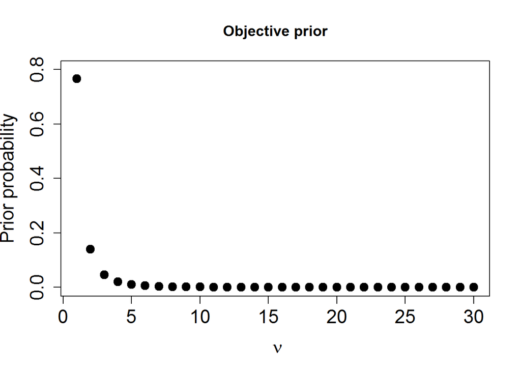

```r
prior = Vectorize(function(nu){
  var =ifelse(nu<(numax-1), exp( T2[nu,3]),exp( T2[nu,2]))
  return(var-1)
})

vec = 1:numax
pr1 = prior(vec)
npr1 = pr1/sum(pr1)

lprior = Vectorize(function(nu) log(npr1[nu]))

# Objective prior for nu
plot(npr1,ylim=c(0,0.8),xlab=~nu,ylab="Prior probability",main="Objective prior",cex.axis=1.5,cex.lab=1.5,pch=19,cex=1.5)
```

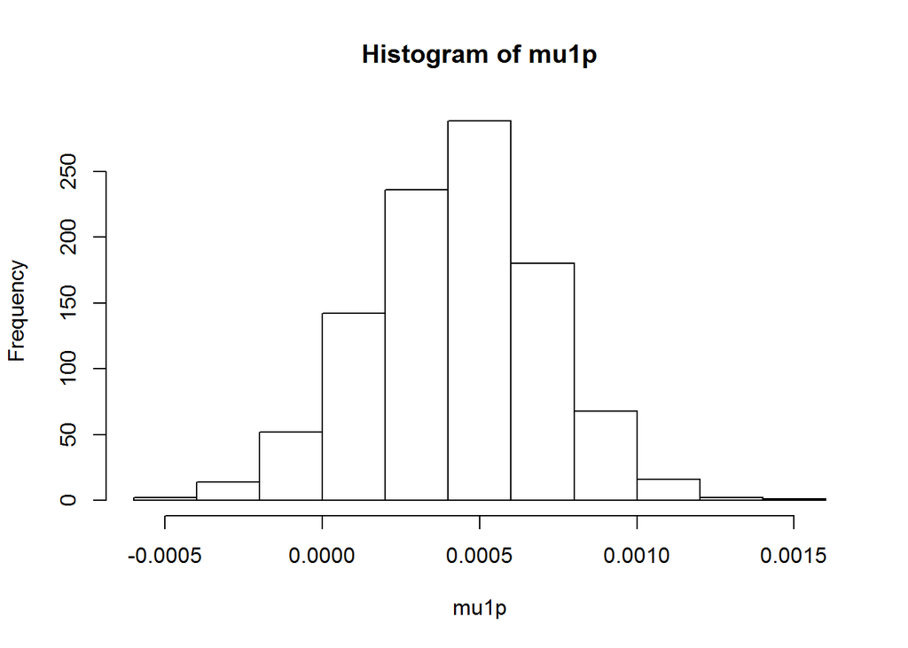

```r
##############################################################################################
# log posterior
##############################################################################################

lpt = function(par){
  if(par[3]>0 & par[5]>0 & par[6]>0 & par[6]<31 & par[6]%%1==0){
    mu = par[1:2]
    A = matrix(c(par[3], par[4], 0, par[5]), nrow = 2, byrow = T)
    Sigma = t(A) %*% A
    var = dmvt(Y, delta = mu, sigma = Sigma, df = par[6], log = TRUE,type = "shifted")
    return( sum(var) + lprior(par[6]) - 1.5*log(det(Sigma)) )
  }
  else return(-Inf)
}


# Function to sample from the discrete parameter nu
post.samp.nu =function(par) {
  lpr = probr = vector()
  for(k in 1:30) lpr[k] = lpt(c(par[1:5],k))
  for(k in 1:30) probr[k] = 1/sum(exp(lpr-lpr[k]))
  return(sample(1:30, 1, prob = probr))
}

# number of iterations
NS= 55000

# Sampler (Metropolis step for the continuous parameters)
# Approximately 10 minutes running time (status bar available)
samp = matrix(0,nrow=NS,ncol=6)
samp[1,] = start
# Initiate the status bar
#sb <- txtProgressBar(min = 0, max = NS, style = 3)

for(i in 2:NS){
  samp[i,6] =  post.samp.nu(samp[i-1,1:5])
  tempf = function(par) lpt(c(par,samp[i,6]))
  samp[i,1:5] = metrop(tempf, samp[i-1,1:5], 1, scale = c(0.0003,0.0001,0.0002,0.0001,0.0001))$final
  # Update the status var
 # setTxtProgressBar(sb, i)
}

# Some histograms and traceplots
burn = 5000
thin =  50
index = seq(burn,NS,thin)

mu1p = samp[index,1]
mu2p = samp[index,2]
sigma1p = samp[index,3]
sigma2p = samp[index,4]
sigma3p = samp[index,5]
nup = samp[index,6]

hist(mu1p)
```

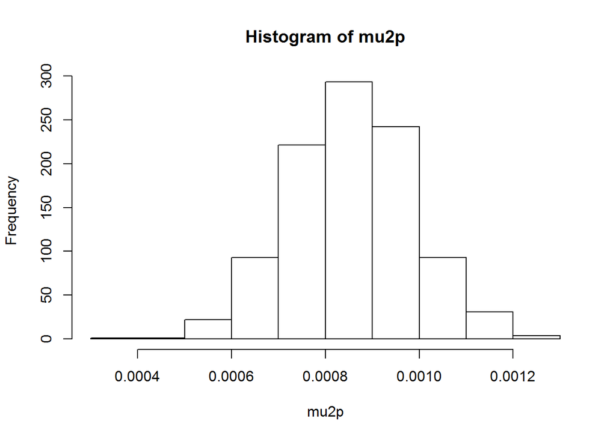

```r
hist(mu2p)
```

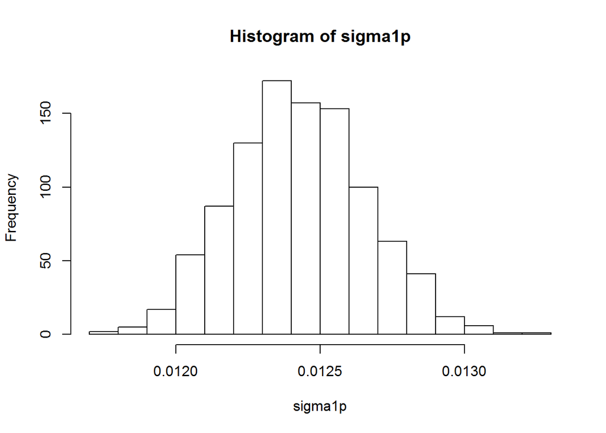

```r
hist(sigma1p)
```

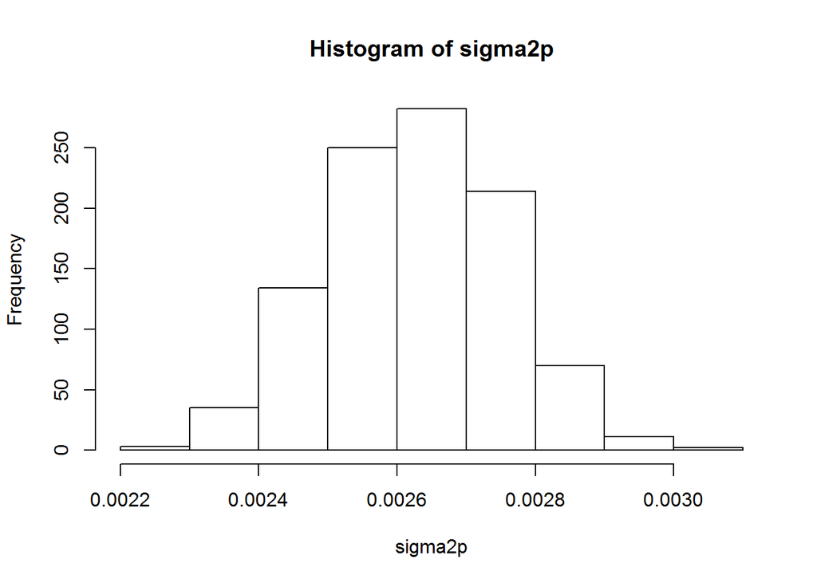

```r
hist(sigma2p)
```

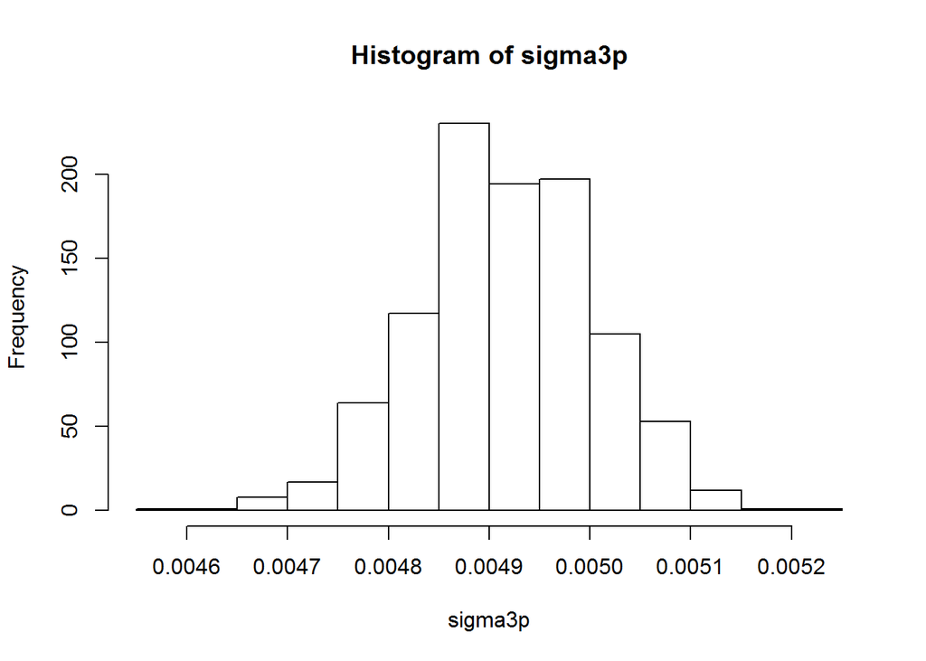

```r
hist(sigma3p)
```

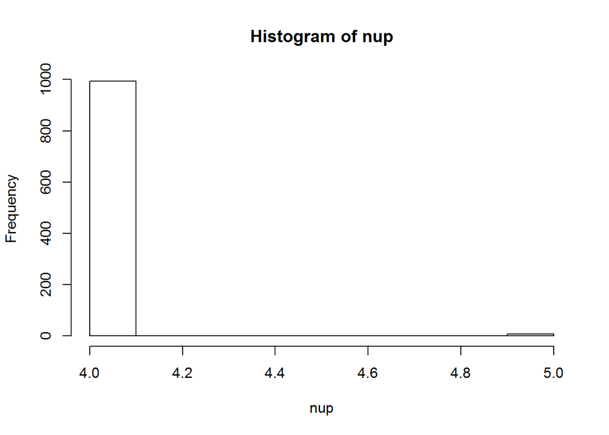

```r
hist(nup)
```

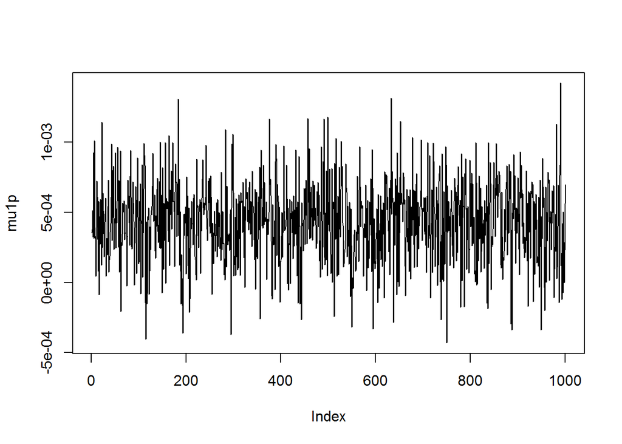

```r
plot(mu1p,type="l")
```

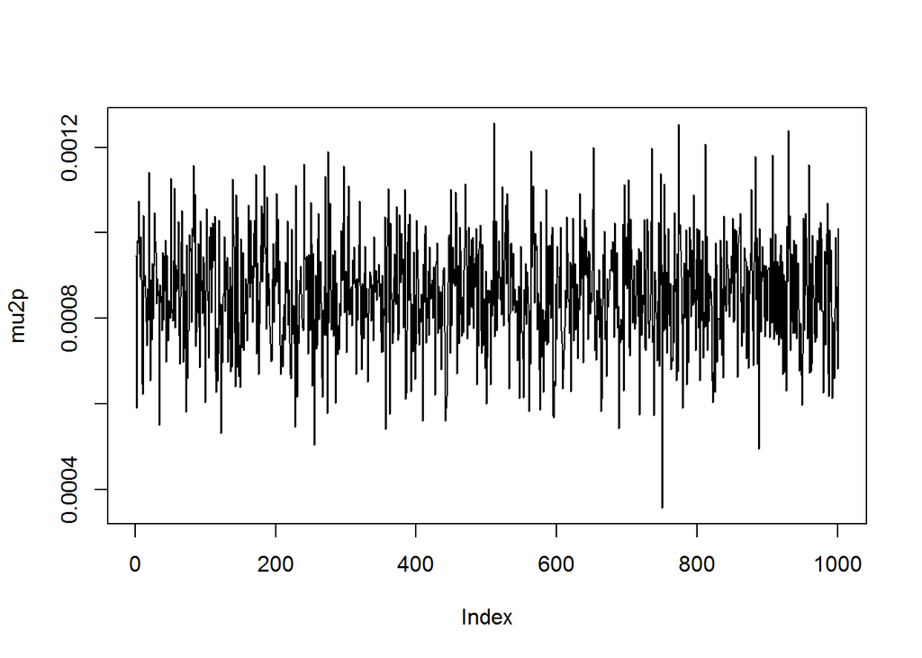

```r
plot(mu2p,type="l")
```

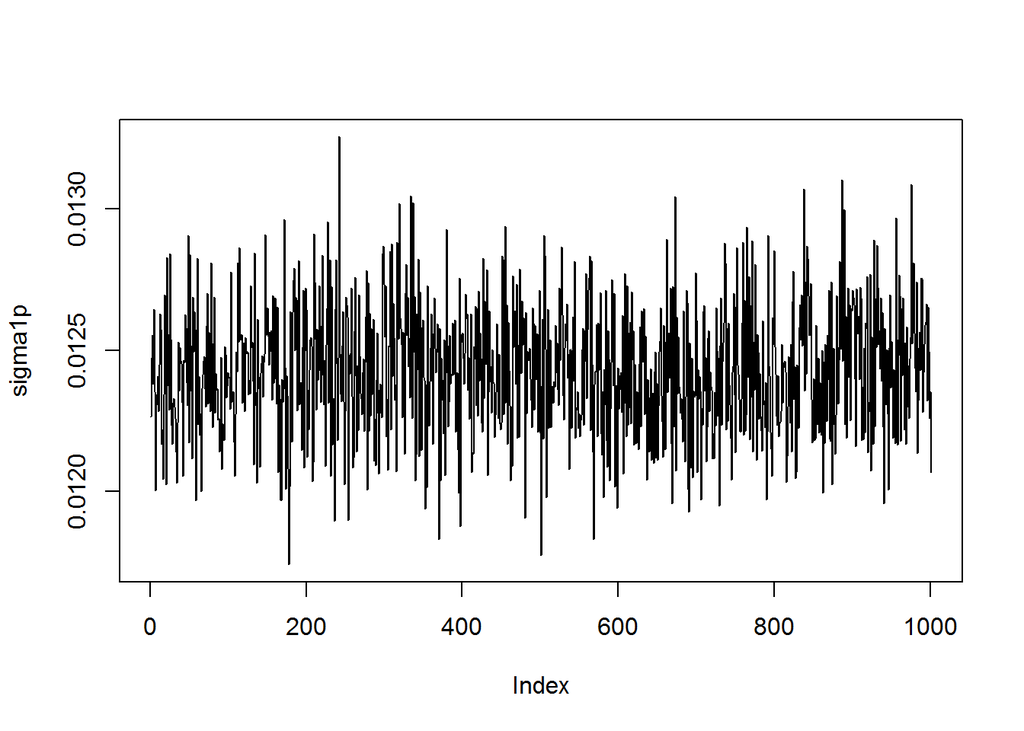

```r
plot(sigma1p,type="l")
```

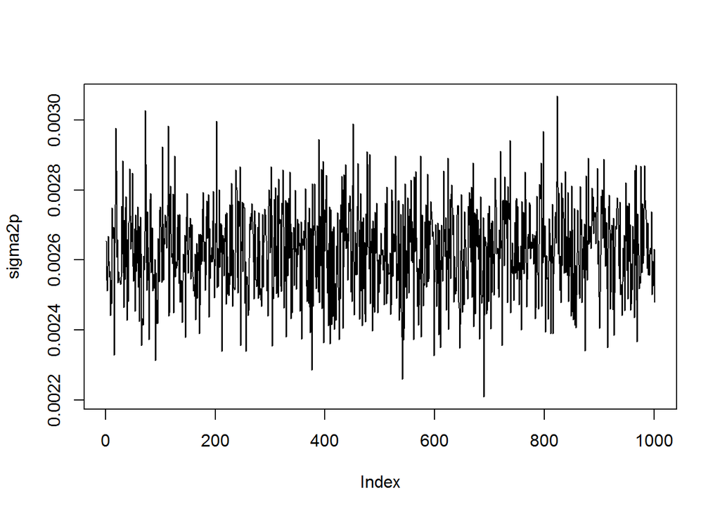

```r
plot(sigma2p,type="l")
```

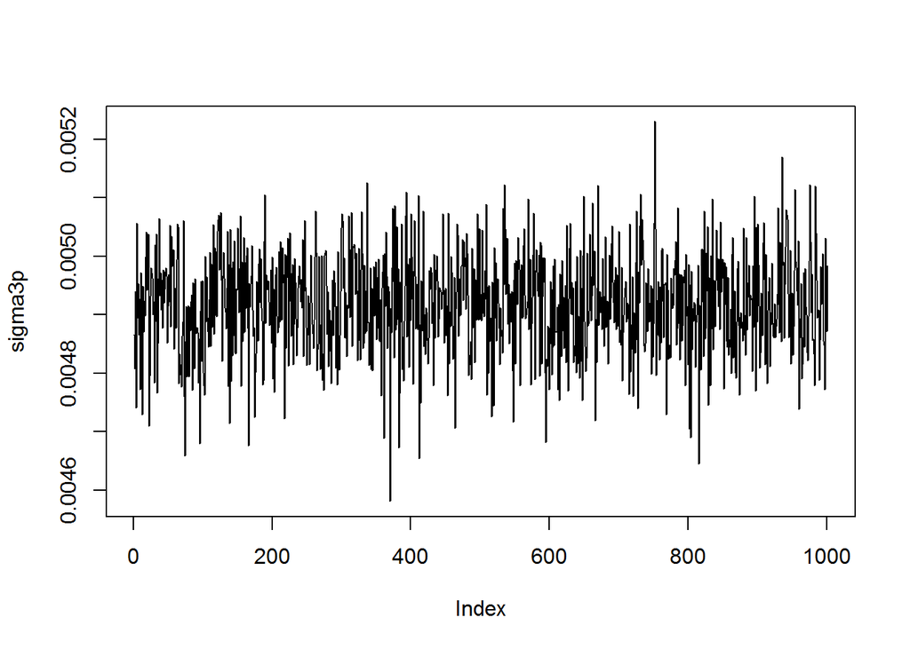

```r
plot(sigma3p,type="l")
```

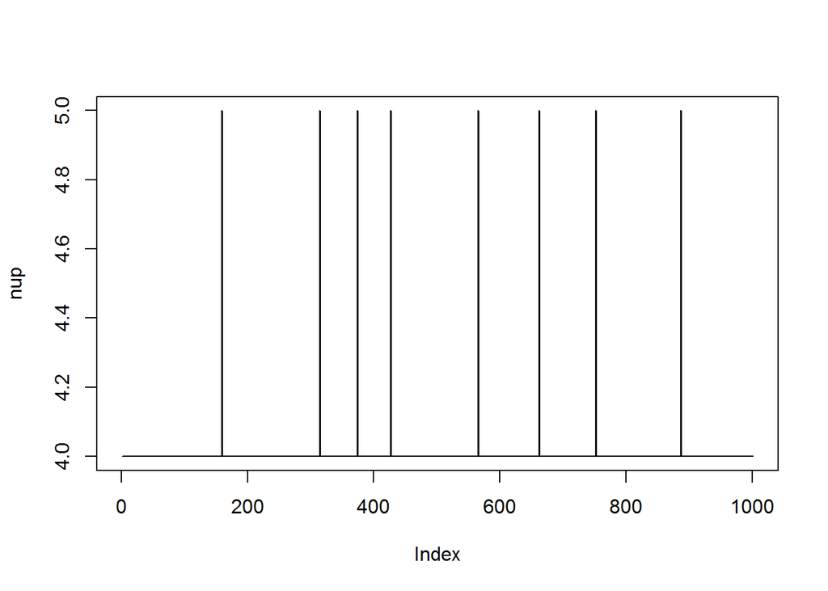

```r
plot(nup,type="l")
```

```r
# Comparing posterior means with MLE
colMeans(samp[index,])
```

```
## [1] 0.0004301167 0.0008573191 0.0124271193 0.0026263064 0.0049170305
## [6] 4.0079920080
```

```r
OPT$par
```

```
## [1] 0.0004990631 0.0008414805 0.0125729426 0.0026557420 0.0049487891
## [6] 4.1890062126
```

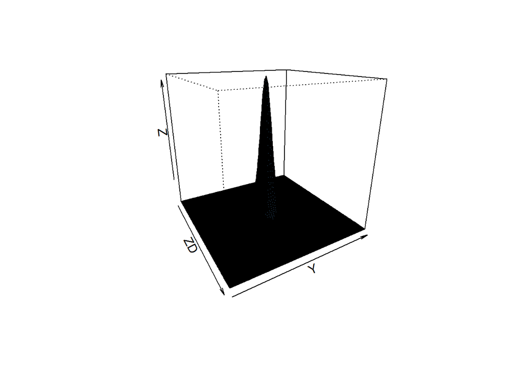

```r
###############################################################################
# Posterior density plots using the posterior mean estimators
###############################################################################

postmean = colMeans(samp[index,])

post.mean.den = function(x){
  mu = postmean[1:2]
  A = matrix(c(postmean[3], postmean[4], 0, postmean[5]), nrow = 2, byrow = T)
  Sigma = t(A) %*% A
  var = dmvt(x, delta = mu, sigma = Sigma, df = postmean[6], type = "shifted",log=FALSE)
  return(var)
}

library(fMultivar)
# Bivariate fitted posterior density
x <- (-100:100)/1000
X <- grid2d(x)
z <- apply(cbind(X$x,X$y),1,post.mean.den)

ZD <- list(x = x, y = x, z = matrix(z, ncol = length(x)))
# Perspective Density Plot:
persp(ZD, theta = 60, phi = 20, col = "steelblue")
```

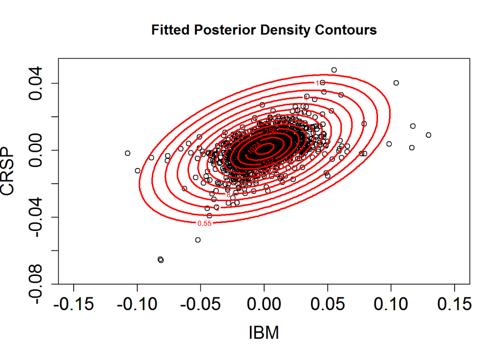

```r
# Contour Density Plot:
plot(as.vector(Y[,1]),as.vector(Y[,2]),xlim=c(-0.15,0.15),ylim=c(-0.075,0.05), main="Fitted Posterior Density Contours",xlab="IBM",ylab="CRSP",cex.axis=1.5,cex.lab=1.5)
par(new=TRUE)
contour(ZD,levels = c(0.55,1,2,4,8,16,32,64,128,256,512,1024,2048),xlim=c(-0.15,0.15),ylim=c(-0.075,0.05),col="red",cex.axis=1.5,cex.lab=1.5,lwd=2)
```